# Plot in R hw4

張瑜君

2019年3月25日

# 先把需要的檔案叫出來(etf4_csv、etf4.c、etf4.reorder、etf4.xts、etf4_monthly、etf4_returns_xts)。

# 01：最後會顯示出折線圖。

橫軸為日期。

```r
library(readr)
etf4_csv<-read_csv("ETF4_2000_2018_d.csv", locale = locale(encoding='big5'))
etf4.c<-etf4_csv[, c(-2, -4)]
etf4.c<-etf4.c[-1,]
colnames(etf4.c)<-c("id", "date", "price")
library(reshape2)
etf4.reorder = dcast(etf4.c, date~id)
etf4.reorder$date<-as.Date(as.character(etf4.reorder$date), "%Y%m%d")
dim(etf4.reorder)
```

```
## [1] 2474    5
```

```r
head(etf4.reorder)
```

```
##         date  0050  0056 006205 00646
## 1 2009-01-05    NA 14.00     NA    NA
## 2 2009-01-06 34.21 14.02     NA    NA
## 3 2009-01-07 34.59 14.28     NA    NA
## 4 2009-01-08 33.21 13.86     NA    NA
## 5 2009-01-09 32.32 13.61     NA    NA
## 6 2009-01-10 31.91 13.55     NA    NA
```

```r
str(etf4.reorder)
```

```
## 'data.frame':    2474 obs. of  5 variables:
##  $ date  : Date, format: "2009-01-05" "2009-01-06" ...
##  $ 0050  : num  NA 34.2 34.6 33.2 32.3 ...
##  $ 0056  : num  14 14 14.3 13.9 13.6 ...
##  $ 006205: num  NA NA NA NA NA NA NA NA NA NA ...
##  $ 00646 : num  NA NA NA NA NA NA NA NA NA NA ...
```

```r
library(xts)
etf4.xts<-xts(etf4.reorder[,-1], order.by= etf4.reorder$date)
head(etf4.xts)
```

```
##             0050  0056 006205 00646
## 2009-01-05    NA 14.00     NA    NA
## 2009-01-06 34.21 14.02     NA    NA
## 2009-01-07 34.59 14.28     NA    NA
## 2009-01-08 33.21 13.86     NA    NA
## 2009-01-09 32.32 13.61     NA    NA
## 2009-01-10 31.91 13.55     NA    NA
```

```r
tail(etf4.xts)
```

```
##             0050  0056 006205 00646
## 2018-12-22 74.75 24.15  25.08 22.93
## 2018-12-24 74.67 24.16  25.25 22.72
## 2018-12-25 73.57 23.90  24.90 22.51
## 2018-12-26 73.87 23.83  25.16 22.13
## 2018-12-27 74.81 23.96  25.30 22.95
## 2018-12-28 75.21 23.92  25.24 23.16
```

```r
str(etf4.xts)
```

```
## An 'xts' object on 2009-01-05/2018-12-28 containing:
##   Data: num [1:2474, 1:4] NA 34.2 34.6 33.2 32.3 ...
##  - attr(*, "dimnames")=List of 2
##   ..$ : NULL
##   ..$ : chr [1:4] "0050" "0056" "006205" "00646"
##   Indexed by objects of class: [Date] TZ: UTC
##   xts Attributes:
##  NULL
```

```r
library(quantmod)
etf4_monthly <- to.monthly(etf4.xts, indexAt = "lastof", OHLC=FALSE)
head(etf4_monthly)
```

```
##             0050  0056 006205 00646
## 2015-12-31 60.75 21.81  31.97 20.07
## 2016-01-31 59.51 21.48  26.21 19.21
## 2016-02-29 61.25 22.39  25.90 19.22
## 2016-03-31 64.82 22.44  27.83 19.73
## 2016-04-30 61.63 21.58  27.17 19.82
## 2016-05-31 63.10 21.86  27.10 20.31
```

```r
library(PerformanceAnalytics)
library(magrittr)
etf4_returns_xts <-Return.calculate(etf4_monthly, method = "log") %>%
  na.omit()
head(etf4_returns_xts)
```

```
##                   0050        0056       006205         00646
## 2016-01-31 -0.02062272 -0.01524631 -0.198656946 -0.0437951860
## 2016-02-29  0.02881948  0.04149216 -0.011898049  0.0005204268
## 2016-03-31  0.05665035  0.00223065  0.071871607  0.0261889165
## 2016-04-30 -0.05046543 -0.03907812 -0.024001152  0.0045512089
## 2016-05-31  0.02357200  0.01289152 -0.002579696  0.0244218467
## 2016-06-30  0.03335201  0.03196311 -0.017119882 -0.0249265149
```

```r
dim(etf4_returns_xts)
```

```
## [1] 36  4
```

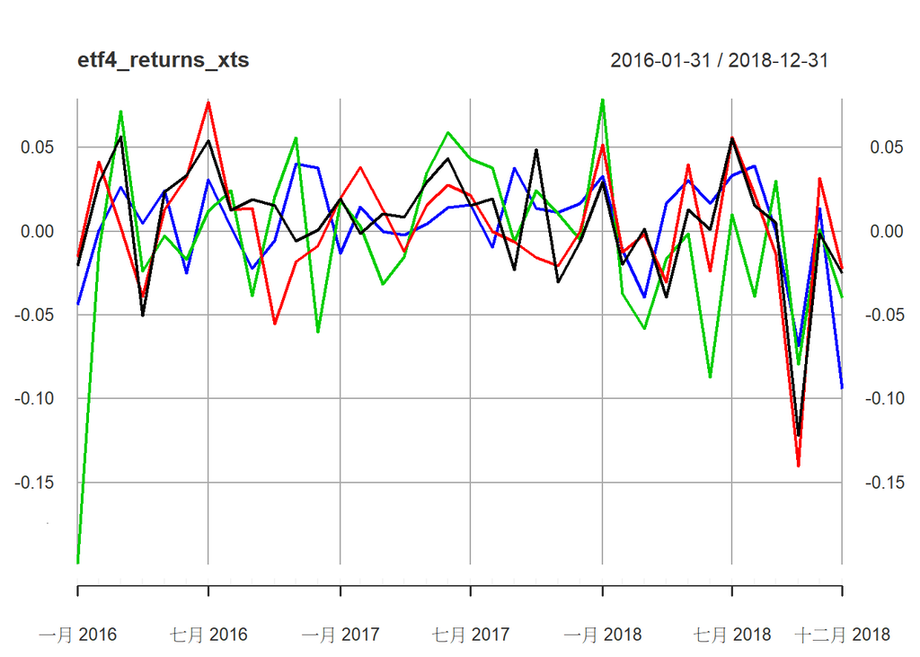

```r
library(ggplot2)
plot(etf4_returns_xts, xaxt='n')
axis(1, index(etf4_returns_xts), format(index(etf4_returns_xts), "%Y/%m"))
```

# 02：利用ggplot2，fortify使物件轉為data.frame。

橫軸為0050，縱軸為00646S&P500。

```r
library(ggplot2)
etf4_ret.df1<-fortify(etf4_returns_xts)
head(etf4_ret.df1)
```

```
##        Index        0050        0056       006205         00646
## 1 2016-01-31 -0.02062272 -0.01524631 -0.198656946 -0.0437951860
## 2 2016-02-29  0.02881948  0.04149216 -0.011898049  0.0005204268
## 3 2016-03-31  0.05665035  0.00223065  0.071871607  0.0261889165
## 4 2016-04-30 -0.05046543 -0.03907812 -0.024001152  0.0045512089
## 5 2016-05-31  0.02357200  0.01289152 -0.002579696  0.0244218467
## 6 2016-06-30  0.03335201  0.03196311 -0.017119882 -0.0249265149
```

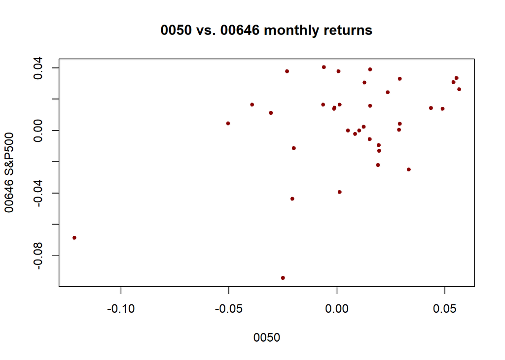

```r
plot(etf4_ret.df1$`0050`, etf4_ret.df1$`00646`, pch=20,
     col = 'darkred', main = '0050 vs. 00646 monthly returns',
     xlab = '0050', ylab = '00646 S&P500')
```

# 03：利用lubridate。

橫軸為etf4_ret.df2$0050，縱軸為etf4_ret.df2$0056。

點的顏色由深藍色到淺藍色為3月、6月、9月、12月。

```r
library(lubridate)
```

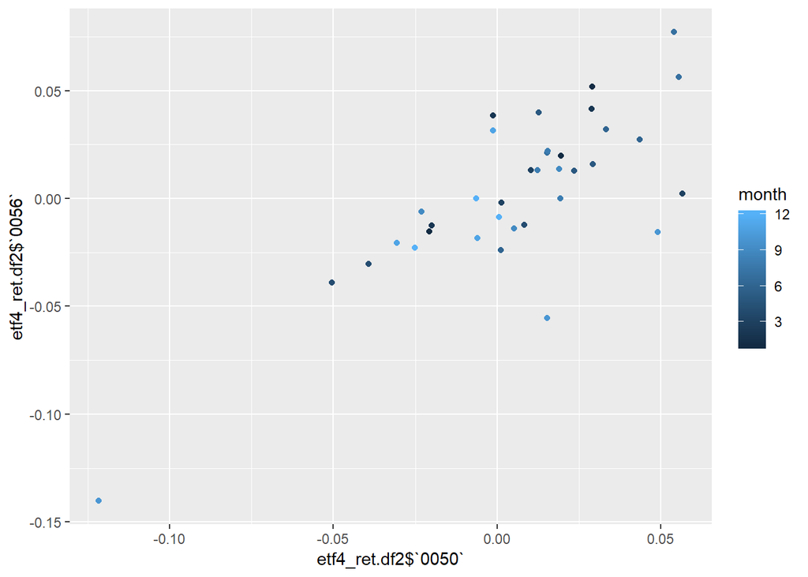

```r
etf4_ret.df2 <- cbind(etf4_ret.df1, month=month(index(etf4_returns_xts)),
                year=year(index(etf4_returns_xts)))
ggplot(data = etf4_ret.df2) +
  geom_point(mapping = aes(x = etf4_ret.df2$`0050`, y = etf4_ret.df2$`0056`, color = month))
```

# 04：

橫軸為etf4_ret.df2$0050，縱軸為etf4_ret.df2$0056。

點的大小由小到大為3月、6月、9月、12月。

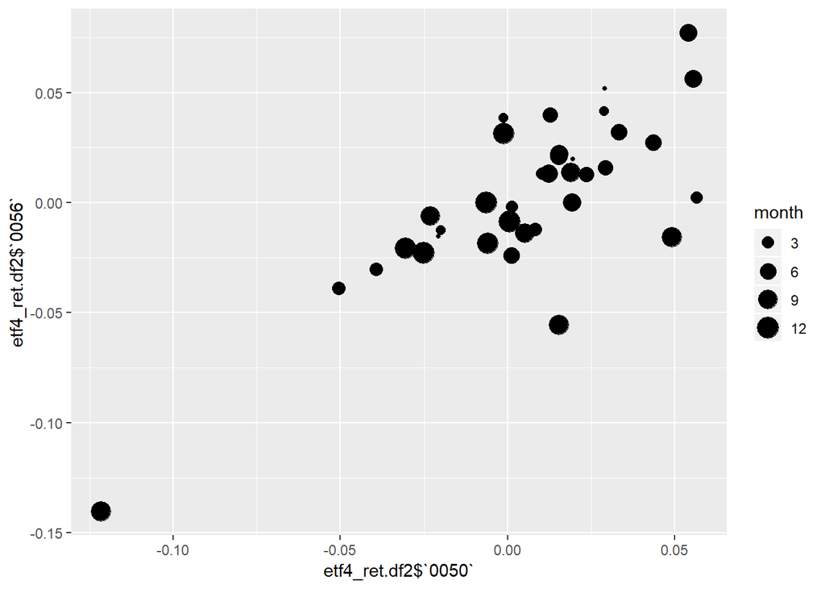

```r
ggplot(data = etf4_ret.df2) +
  geom_point(mapping = aes(x = etf4_ret.df2$`0050`, y = etf4_ret.df2$`0056`, size = month))
```

# 05：

橫軸為etf4_ret.df2$0050，縱軸為etf4_ret.df2$0056。

點的alpha粒子顏色由淺到深為3月、6月、9月、12月。

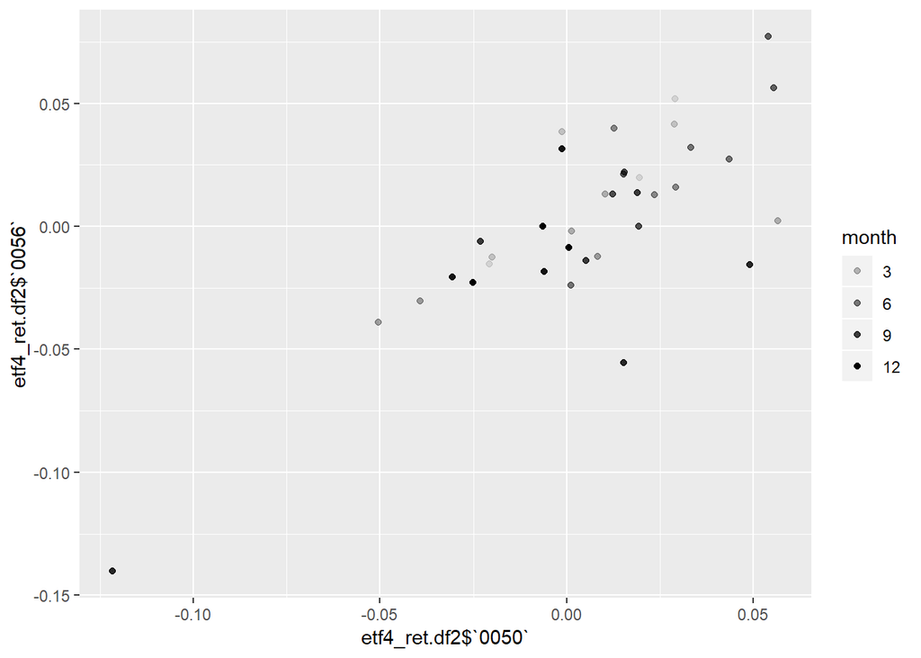

```r
ggplot(data = etf4_ret.df2) +
  geom_point(mapping = aes(x = etf4_ret.df2$`0050`, y = etf4_ret.df2$`0056`, alpha = month))
```

# 06：

圖為折線圖，橫軸為Index，縱軸為Value。

粉紅色為0050，綠色為0056，藍色為006205，紫色為00646。

```r
etf4_ret.df<-fortify(etf4_returns_xts, melt=TRUE)
head(etf4_ret.df)
```

```
##        Index Series       Value
## 1 2016-01-31   0050 -0.02062272
## 2 2016-02-29   0050  0.02881948
## 3 2016-03-31   0050  0.05665035
## 4 2016-04-30   0050 -0.05046543
## 5 2016-05-31   0050  0.02357200
## 6 2016-06-30   0050  0.03335201
```

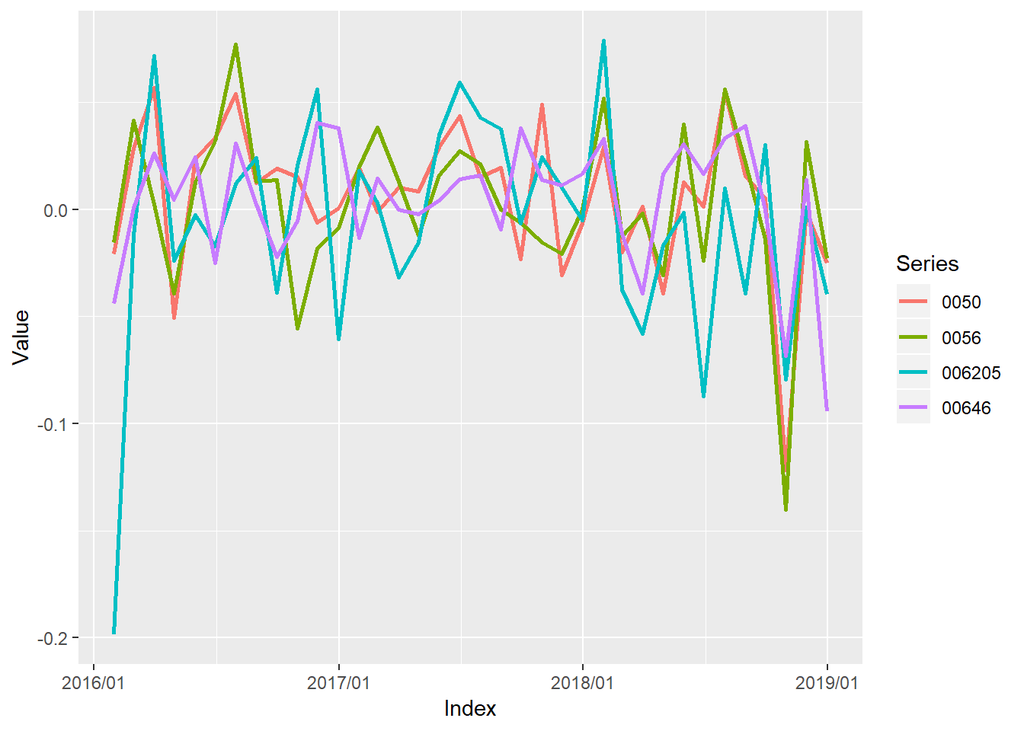

```r
p<-ggplot(etf4_ret.df, aes(x = Index, y = Value))+
  geom_line(aes(color = Series), size = 1)

p + scale_x_date(date_labels = "%Y/%m")
```

# 07：標題為Monthly Returns。

粉紅色為0050，綠色為0056，藍色為006205，紫色為00646。

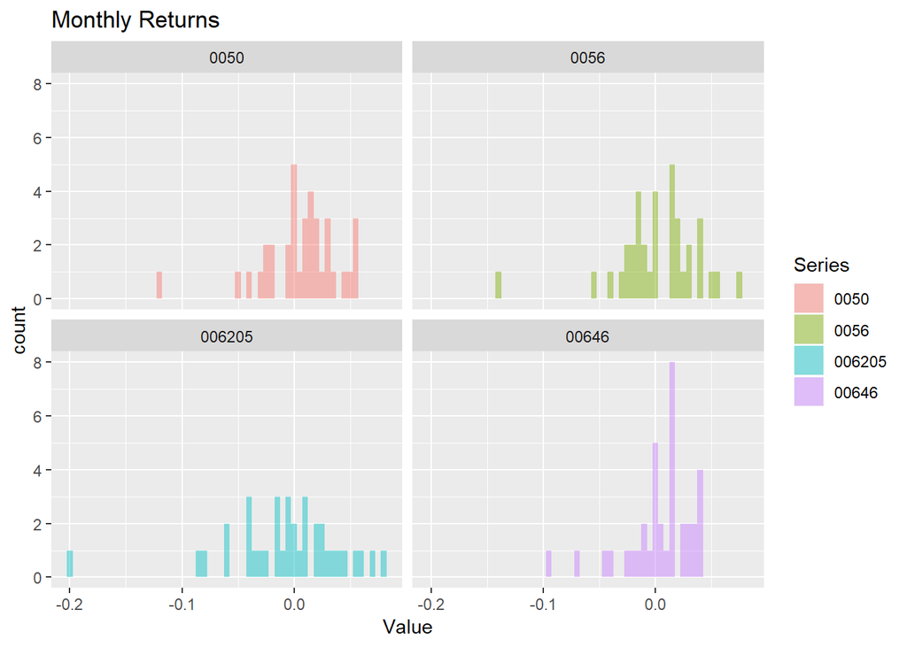

```r
q<-etf4_ret.df %>%
  ggplot(aes(x =Value, fill = Series)) +
  geom_histogram(alpha = 0.45, binwidth = .005) +
  ggtitle("Monthly Returns")
q + facet_wrap(~Series)+ theme_update(plot.title = element_text(hjust = 0.5))
```

# 08：標題為Monthly Returns Density Since 2016。

橫軸為monthly returns，縱軸為distribution。

粉紅色為0050，綠色為0056，藍色為006205，紫色為00646。

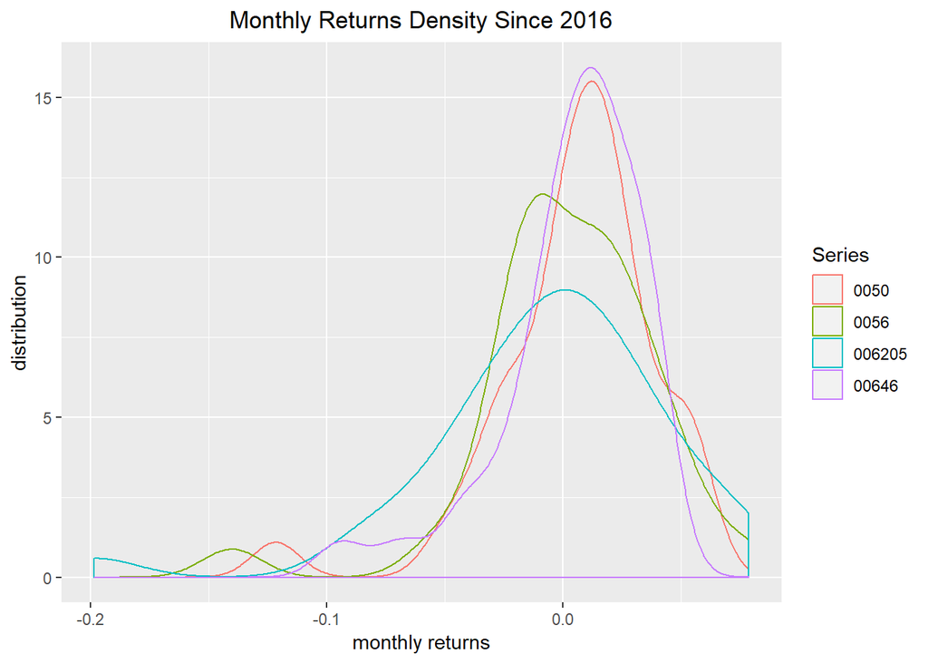

```r
etf4_ret.df %>%
  ggplot(aes(x = Value, colour = Series)) +
  geom_density(alpha = 1) +
  ggtitle("Monthly Returns Density Since 2016") +
  xlab("monthly returns") +
  ylab("distribution") +
  theme_update(plot.title = element_text(hjust = 0.5))
```

# 09：將07、08的圖合併起來。

圖的標題為Monthly Returns Since 2016。

橫軸為monthly returns，縱軸為distribution。

粉紅色為0050，綠色為0056，藍色為006205，紫色為00646。

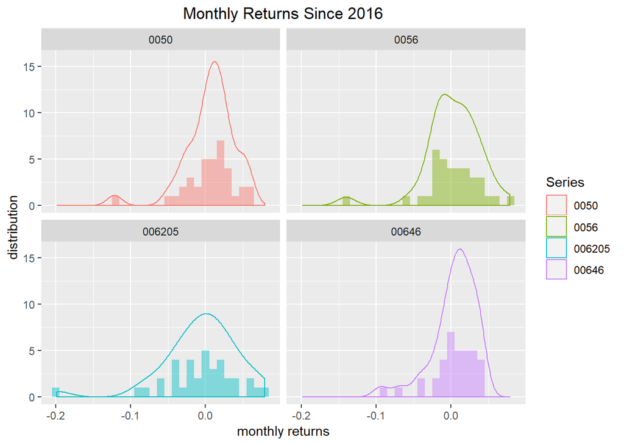

```r
etf4_ret.df %>%
  ggplot(aes(x = Value)) +
  geom_density(aes(color = Series), alpha = 1) +
  geom_histogram(aes(fill = Series), alpha = 0.45, binwidth = .01) +
  guides(fill = FALSE) +
  facet_wrap(~Series) +
  ggtitle("Monthly Returns Since 2016") +
  xlab("monthly returns") +
  ylab("distribution") +
  theme_update(plot.title = element_text(hjust = 0.5))
```